# Análisis Estadístico en Inferencia para Investigación Médica

Wilson Eduardo Jerez-Hernández

2024-03-02

Abstract

En este ejercicio, exploramos la inferencia estadística aplicada a una investigación médica centrada en determinar la probabilidad de éxito de un nuevo tratamiento médico. El objetivo es asegurar al menos un 55% de efectividad, y se utiliza la fracción de pacientes que responden positivamente como estimador clave. Analizamos las características del estimador, su distribución, y aplicamos la Aproximación de la Binomial por la Normal. Este enfoque proporciona una perspectiva estadística en el contexto médico.

# 1. Introducción

En este ejercicio, nos enfocaremos en la inferencia estadística aplicada a una investigación médica. El objetivo es determinar la probabilidad de éxito de un nuevo tratamiento médico, asegurando al menos un 55% de efectividad. Exploraremos el proceso de inferencia y sus implicaciones en este escenario específico.

# 2. Descripción de la Población

Supongamos que se considera exitoso un tratamiento médico si al menos el 55% de los pacientes tratados muestran mejoría. La pregunta clave es: ¿Cuál es la probabilidad de alcanzar este umbral de efectividad cuando se selecciona aleatoriamente un grupo de $n = 100$ pacientes?

**Contexto Adicional:** Se estima que aproximadamente el 50% de los pacientes responderán positivamente al tratamiento.

```r
set.seed(42)
n <- 100 # Muestra
p <- 0.5 # Estimación
Datos <- rbinom(n, 1, p) # Distribución Bernoulli
Datos
```

```
##   [1] 1 1 0 1 1 1 1 0 1 1 0 1 1 0 0 1 1 0 0 1 1 0 1 1 0 1 0 1 0 1 1 1 0 1 0 1 0
##  [38] 0 1 1 0 0 0 1 0 1 1 1 1 1 0 0 0 1 0 1 1 0 0 1 1 1 1 1 1 0 0 1 1 0 0 0 0 0
##  [75] 0 1 0 0 1 0 1 0 0 1 1 1 0 0 0 0 1 0 0 1 1 1 0 1 1 1
```

```r
table(Datos)
```

```
## Datos
##  0  1
## 45 55
```

```r
Frecuencia <- mean(Datos)
Frecuencia
```

```
## [1] 0.55
```

## 2.1 Solución Detallada

- **Objetivo:** Determinar la probabilidad de éxito del tratamiento médico, garantizando al menos un 55% de efectividad en un grupo aleatorio de $n = 100$ pacientes.
- **Parámetros de la Población:**
  - Población de Interés: Pacientes sometidos al tratamiento médico.
  - Umbral de Éxito: 55% de pacientes que deben mostrar mejoría.
  - Distribución Poblacional: Binomial con $n = 100$, $p = 0.5$ (probabilidad de éxito estimada) y $q=1-p=0.5$.

# 3. Identificación del Estimador Apropiado

- **Estimador Clave:** La fracción de pacientes que responden positivamente, representada por $Y/n$ ($Y$ el número de pacientes que responden positivamente al tratamiento).
- **Método:** Calcular la proporción muestral de pacientes que responden positivamente al tratamiento y que es mayor o igual al 55%, representada por $Y/n$.

```r
Y <- sum(Datos) # Y es el exito de la muestra (Cantidad de 1 en la distribución de bernoulli)
estimador_muestra <- Y / n
cat("Estimador de la proporción de éxito:", estimador_muestra)
```

```
## Estimador de la proporción de éxito: 0.55
```

# 4. Demostración de Características del Estimador

- **Definición del Estimador:** $\frac{Y}{n} = \frac{1}{n} \sum_{i=1}^{n} X_i$, donde $X_i = 1$ si el paciente $i$ responde positivamente, y $X_i = 0$ en caso contrario.
- **Independencia de $X_i$:** Suponiendo independencia de las respuestas de los pacientes.

# 5. Distribución del Estimador

- En el libro *Estadística Matemática con Aplicaciones* (Wackerly, Mendenhall, and Scheaffer 2014) se explica que el teorema del límite central implica que $X = \frac{Y}{n}$ se distribuye aproximadamente de manera normal con media $p = 0.5$ y varianza $\frac{pq}{n} = \frac{(0.5)(0.5)}{100} = 0.0025$ para muestras grandes.

```r
m <- 10000 # número de simulaciones
datos <- matrix(nrow = m, ncol = n)
for (i in 1:m) {
  datos[i,] <- rbinom(n, 1, p)
}
datos <- data.frame(datos) # DataFrame con 1000 obs, y 100 muestras.
SumaXi <- apply(datos,1,sum)
SumaXi <- data.frame(SumaXi)
media <- apply(datos, 1, mean)
SumaXi <- cbind(SumaXi, media)
head(SumaXi)
```

|  | SumaXi | media |
| --- | --- | --- |
| 1 | 56 | 0.56 |
| 2 | 38 | 0.38 |
| 3 | 46 | 0.46 |
| 4 | 40 | 0.40 |
| 5 | 49 | 0.49 |
| 6 | 47 | 0.47 |

# 6. Aproximación de la Binomial por la Normal

- **Justificación:** Basada en el Teorema del Límite Central.
- **Condiciones de Validez:** Validez para muestras grandes.

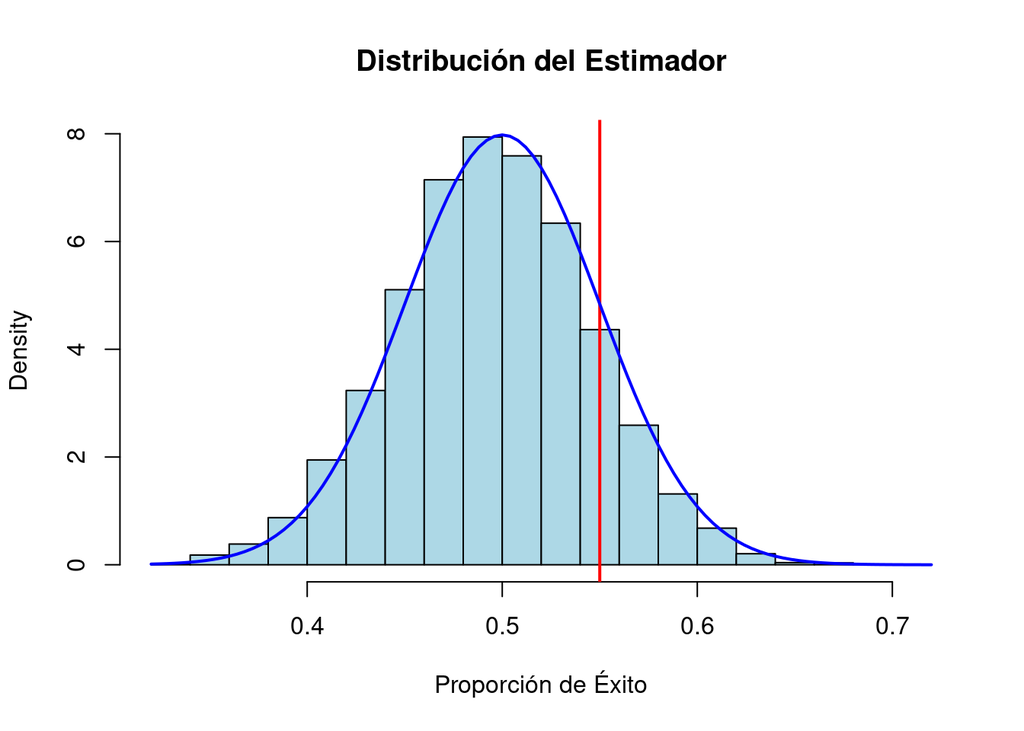

```r
hist(media, main="Distribución del Estimador", xlab="Proporción de Éxito",
     col="lightblue", border="black",prob=TRUE)
abline(v = Frecuencia, col="red", lwd=2)
# Ajustar una curva a la distribución del estimador
curve(dnorm(x, mean = 0.5, sd = sqrt(p * (1 - p) / n)),
      col = "blue", lwd = 2, add = TRUE)
```

## Cálculos y Resultados

Probabilidad de Éxito: $P\left(\frac{Y}{n} \geq 0.55\right) = P\left(\frac{Y/n - 0.5}{\sqrt{0.0025}} \geq \frac{0.55 - 0.50}{0.05}\right)$

Aproximación por la Normal: $\approx P(Z \geq 1) = 0.1587$

```r
# Calcular P(Z >= 1) utilizando pnorm
prob <- 1 - pnorm(1)

# Imprimir el resultado
cat("P(Z >= 1) =", round(prob, 4))
```

```
## P(Z >= 1) = 0.1587
```

# Referencias

Wackerly, Dennis D., William Mendenhall, and Richard L. Scheaffer. 2014. *Estadística Matemática Con Aplicaciones*. 7th edition. México: Cengage Learning Editores.